# Math 150 Survival Analysis Project Test Code

Carrie Saada

May 2, 2019

```r
knitr::opts_chunk$set(message=FALSE, warning=FALSE, fig.height=4, fig.width=5,
                      fig.align = "center")
library(tidyverse)
library(broom)
library(survival)
library(survminer)
library(coxed)
```

# Importing data:

```r
AD = read.csv("AIDSdata.csv")
```

# Trying to do power analysis

```r
null = sim.survdata(851, 100, x = 1, beta = 0, censor = (851 - 69)/851)
alt = sim.survdata(851, 100, x= 1, beta = -1.454, censor = (851 - 69)/851)
#alt$data$y
cx = coxph(Surv(y, failed) ~ X, data = alt$data)
#coxph(Surv(y, failed) ~ X, data = null$data)
scx = summary(cx)
pval = scx$waldtest[3]
```

X might be the number of covariates?

```r
loopVals = c(1:50)
output = rep(NA, length(loopVals))
#output
for(i in loopVals){
  loopSim = sim.survdata(851, 100, x= 1, beta = -1.454, censor = (851 - 69)/851)
  pval = summary(coxph(Surv(y, failed) ~ X, data = loopSim$data))$waldtest[3]
  output[i] = pval < 0.05

}
sum(output) / length(output)
```

```r
betaVals = c(0, -0.2, -0.5, -1, -1.454, -1.5, -2, -3)
powersForBeta = rep(NA, length(betaVals))
outerLoop = c(1:length(betaVals)) #loop through betas
innerLoop = c(1:1000) #replicates
for(i in outerLoop){
  pBools = rep(NA, length(innerLoop))
  for(j in innerLoop){
    loopSim = sim.survdata(851, 100, x= 1, beta = betaVals[i], censor = (851 - 69)/851)
    pval = summary(coxph(Surv(y, failed) ~ X, data = loopSim$data))$waldtest[3]
    pBools[j] = pval < 0.05
  }
  powersForBeta[i] = sum(pBools) / length(pBools)
}

powersForBeta
```

```r
popVals = c(100, 400, 800, 851, 1200, 1600, 4000)
powersForPop = rep(NA, length(popVals))
outerLoop = c(1:length(popVals)) #loop through betas
innerLoop = c(1:1000) #replicates
for(i in outerLoop){
  pBools = rep(NA, length(innerLoop))
  for(j in innerLoop){
    loopSim = sim.survdata(popVals[i], 100, x= 1, beta = -1.454, censor = (851 - 69)/851)
    pval = summary(coxph(Surv(y, failed) ~ X, data = loopSim$data))$waldtest[3]
    pBools[j] = pval < 0.05
  }
  powersForPop[i] = sum(pBools) / length(pBools)
}

powersForPop
```

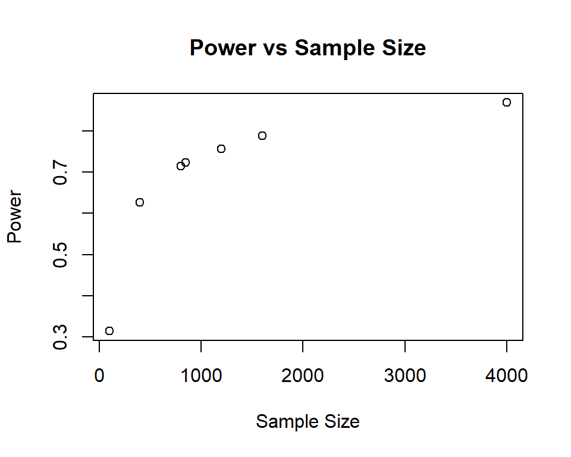

```r
popx = c(100, 400, 800, 851, 1200, 1600, 4000)
popy = c(0.314, 0.626, 0.715, 0.724, 0.757, 0.789, 0.869)
plot(popx, popy, main = "Power vs Sample Size", xlab = "Sample Size", ylab = "Power")
```

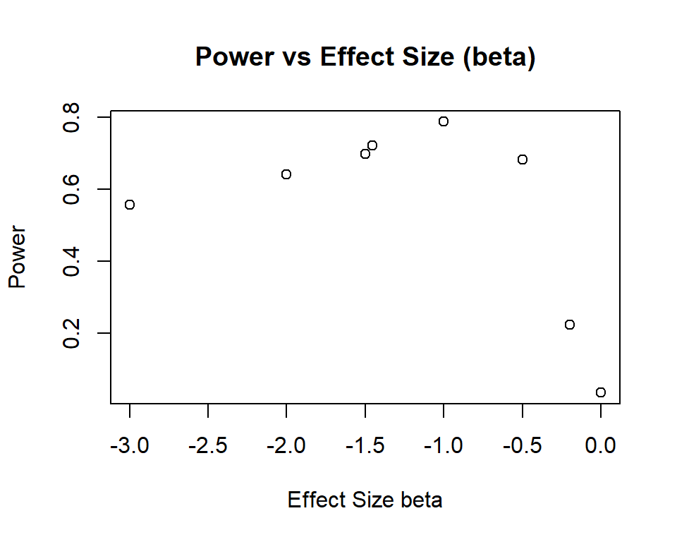

```r
betax = c(0, -0.2, -0.5, -1, -1.454, -1.5, -2, -3)
betay = c(0.036, 0.224, 0.681, 0.787, 0.722, 0.698, 0.641, 0.557)
plot(betax, betay, main = "Power vs Effect Size (beta)", xlab = "Effect Size beta", ylab = "Power")
```

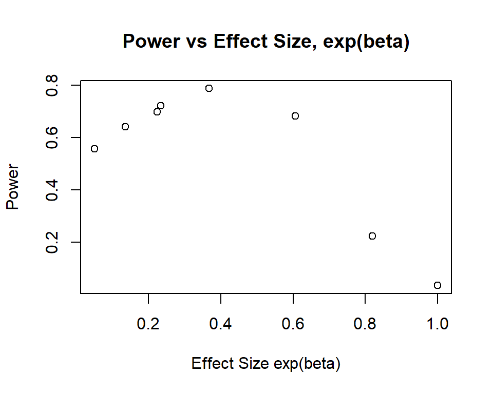

```r
expbetax = c(1.00000000, 0.81873075, 0.60653066, 0.36787944, 0.23363388, 0.22313016, 0.13533528, 0.04978707)
plot(expbetax, betay, main = "Power vs Effect Size, exp(beta)", xlab = "Effect Size exp(beta)", ylab = "Power")
```

Updated power plot

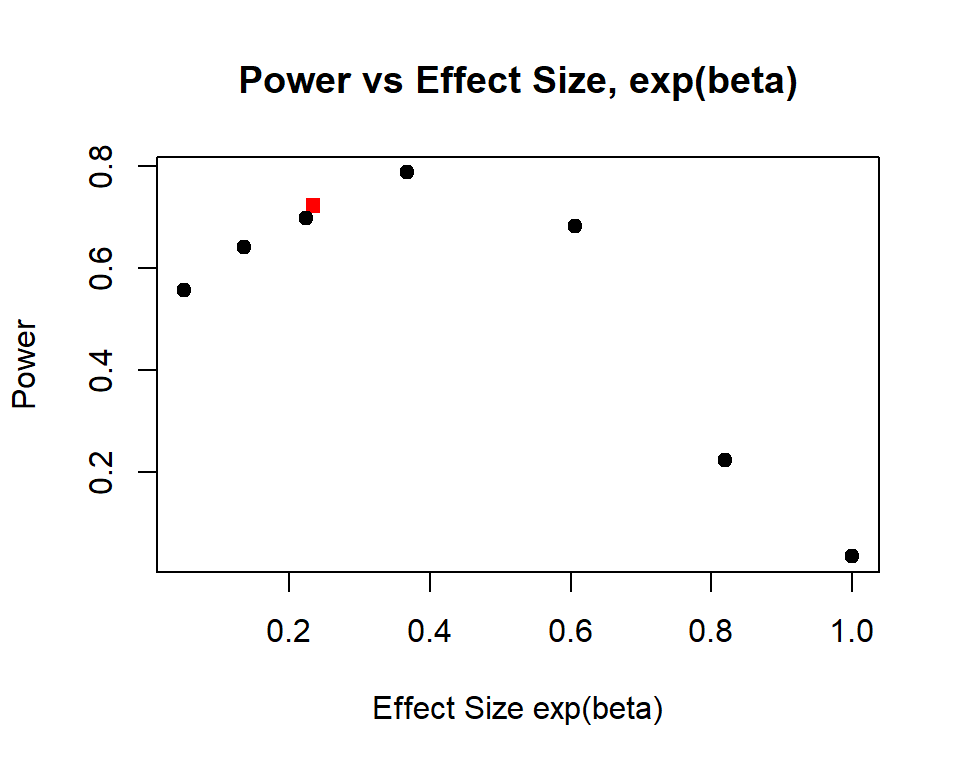

| Beta | Exp(Beta) | Power |
| --- | --- | --- |
| 0 | 1 | 0.036 |
| -0.2 | 0.8187 | 0.224 |
| -0.5 | 0.6065 | 0.681 |
| -1 | 0.3679 | 0.787 |
| **-1.454** | **0.2336** | **0.722** |
| -1.5 | 0.2231 | 0.698 |
| -2 | 0.1353 | 0.641 |
| -3 | 0.0498 | 0.557 |

```r
plot(expbetax, betay, main = "Power vs Effect Size, exp(beta)", xlab = "Effect Size exp(beta)", ylab = "Power", col=ifelse(expbetax==expbetax[5], "red", "black"),pch=ifelse(expbetax==expbetax[5], 15, 19))
```

# Some exploratory plots:

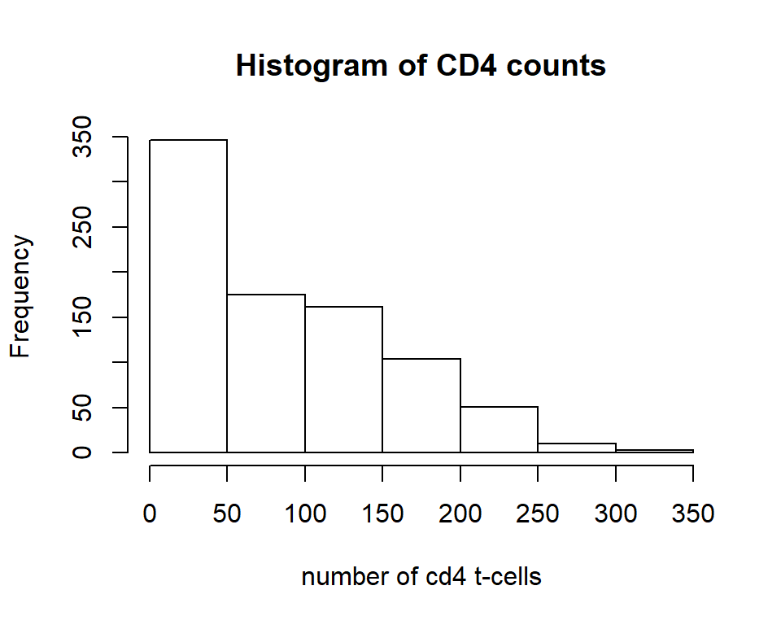

```r
hist(AD$cd4, main = "Histogram of CD4 counts", xlab = "number of cd4 t-cells")
```

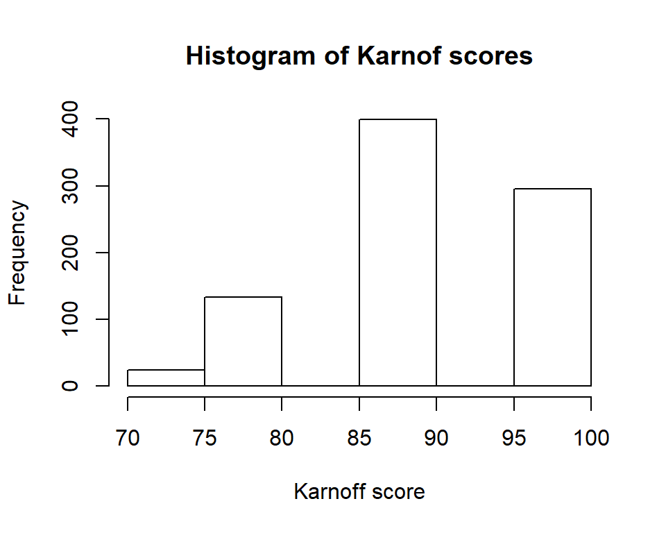

```r
hist(AD$karnof, main = "Histogram of Karnof scores", xlab = "Karnoff score", breaks = 5)
```

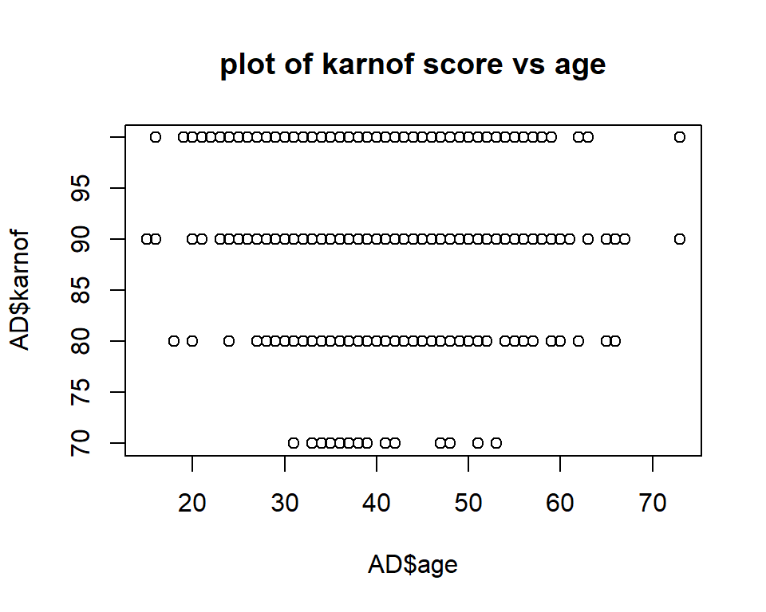

```r
#I'm having a hard time getting the histogram breaks right - karnoff scores are multiples of 10 and it doesn't like that
plot(AD$age, AD$karnof, main = "plot of karnof score vs age")
```

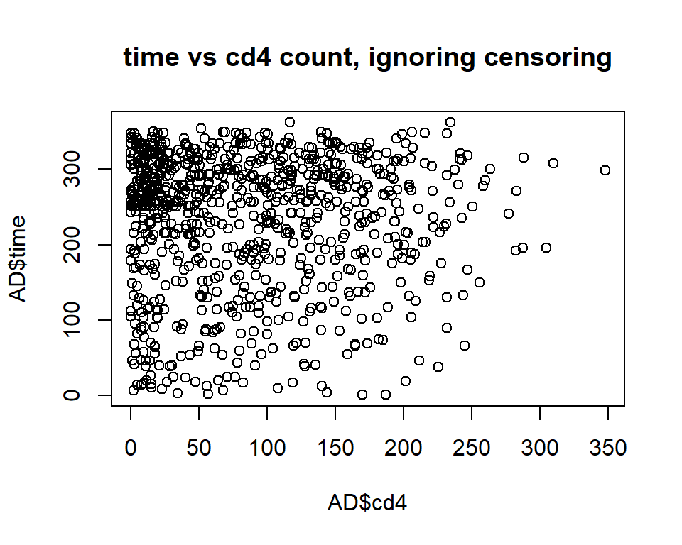

```r
plot(AD$cd4, AD$time, main ="time vs cd4 count, ignoring censoring")
```

## Working on COX model

Variables: Response: time, censor Not using: time.d, censor.d (because we’re using “aids defining event or death”, not just death) Explanatory: tx, txgrp, strat2, sex, raceth, ivdrug, hemophil, karnof, cd4, priorzdv, age

Let’s check if we need interaction. Likelihood ratio test is 2ln(Likelihood of full) - 2ln(Likelihood of reduced)

```r
full = coxph(Surv(time, censor) ~ (tx+strat2+sex+raceth+ivdrug+hemophil+karnof+cd4+priorzdv+age)^2, data = AD)
full$loglik[2]
```

```
## [1] -380.5977
```

```r
red = coxph(Surv(time, censor) ~ tx+strat2+sex+raceth+ivdrug+hemophil+karnof+cd4+priorzdv+age, data = AD)
red$loglik[2]
```

```
## [1] -411.5144
```

```r
length(red$coefficients)
```

```
## [1] 10
```

```r
1 - pchisq(2 * full$loglik[2] - 2 * red$loglik[2], df = length(full$coefficients) - length(red$coefficients))
```

```
## [1] 0.04845761
```

```r
full
```

```
## Call:
## coxph(formula = Surv(time, censor) ~ (tx + strat2 + sex + raceth +
##     ivdrug + hemophil + karnof + cd4 + priorzdv + age)^2, data = AD)
##
##                         coef  exp(coef)   se(coef)      z       p
## tx                -5.501e+00  4.084e-03  4.369e+00 -1.259 0.20807
## strat2            -9.622e-01  3.820e-01  7.284e+00 -0.132 0.89490
## sex                1.137e+01  8.710e+04  5.589e+00  2.035 0.04182
## raceth             7.870e+00  2.617e+03  2.418e+00  3.255 0.00113
## ivdrug            -7.581e+00  5.101e-04  3.252e+00 -2.331 0.01976
## hemophil           1.996e+01  4.646e+08  2.107e+04  0.001 0.99924
## karnof             1.860e-01  1.204e+00  1.246e-01  1.493 0.13539
## cd4               -1.073e-01  8.983e-01  8.413e-02 -1.275 0.20221
## priorzdv           6.378e-02  1.066e+00  8.320e-02  0.767 0.44336
## age                4.436e-01  1.558e+00  2.030e-01  2.185 0.02890
## tx:strat2          1.039e-02  1.010e+00  9.648e-01  0.011 0.99141
## tx:sex             1.969e+00  7.163e+00  7.915e-01  2.487 0.01287
## tx:raceth         -6.084e-02  9.410e-01  3.554e-01 -0.171 0.86408
## tx:ivdrug          9.461e-02  1.099e+00  5.560e-01  0.170 0.86488
## tx:hemophil       -1.611e+01  1.008e-07  4.131e+03 -0.004 0.99689
## tx:karnof          2.166e-02  1.022e+00  3.952e-02  0.548 0.58369
## tx:cd4             5.997e-03  1.006e+00  1.114e-02  0.538 0.59049
## tx:priorzdv       -3.839e-02  9.623e-01  1.685e-02 -2.278 0.02273
## tx:age             3.409e-02  1.035e+00  3.266e-02  1.044 0.29656
## strat2:sex        -2.387e-01  7.876e-01  1.326e+00 -0.180 0.85716
## strat2:raceth     -4.696e-01  6.253e-01  6.182e-01 -0.760 0.44747
## strat2:ivdrug      5.624e-01  1.755e+00  7.919e-01  0.710 0.47756
## strat2:hemophil    1.885e+00  6.585e+00  3.504e+00  0.538 0.59061
## strat2:karnof     -1.333e-02  9.868e-01  5.889e-02 -0.226 0.82091
## strat2:cd4        -2.740e-03  9.973e-01  1.214e-02 -0.226 0.82142
## strat2:priorzdv    4.170e-02  1.043e+00  2.261e-02  1.845 0.06510
## strat2:age         4.497e-02  1.046e+00  4.961e-02  0.906 0.36468
## sex:raceth        -1.886e+00  1.516e-01  6.562e-01 -2.875 0.00404
## sex:ivdrug         4.405e-01  1.553e+00  6.784e-01  0.649 0.51617
## sex:hemophil      -2.067e+01  1.060e-09  2.085e+04 -0.001 0.99921
## sex:karnof        -7.926e-02  9.238e-01  5.430e-02 -1.460 0.14439
## sex:cd4           -8.461e-03  9.916e-01  1.769e-02 -0.478 0.63250
## sex:priorzdv      -3.032e-04  9.997e-01  2.286e-02 -0.013 0.98941
## sex:age           -5.357e-02  9.478e-01  4.356e-02 -1.230 0.21880
## raceth:ivdrug      2.133e-01  1.238e+00  2.426e-01  0.879 0.37933
```

[output cut: 8 more lines]

```
## ivdrug:priorzdv    2.655e-02  1.027e+00  1.055e-02  2.517 0.01182
## ivdrug:age         2.986e-02  1.030e+00  3.208e-02  0.931 0.35186
## hemophil:karnof   -8.703e-02  9.167e-01  1.461e-01 -0.596 0.55134
## hemophil:cd4      -9.746e-03  9.903e-01  4.981e-02 -0.196 0.84486
## hemophil:priorzdv -4.504e-02  9.560e-01  3.127e-02 -1.440 0.14975
## hemophil:age      -7.388e-02  9.288e-01  1.262e-01 -0.586 0.55820
## karnof:cd4         1.096e-03  1.001e+00  6.856e-04  1.599 0.10983
## karnof:priorzdv   -4.181e-04  9.996e-01  7.074e-04 -0.591 0.55454
## karnof:age        -4.056e-03  9.960e-01  2.148e-03 -1.888 0.05905
## cd4:priorzdv      -2.991e-04  9.997e-01  2.646e-04 -1.130 0.25830
## cd4:age            3.926e-04  1.000e+00  5.166e-04  0.760 0.44732
## priorzdv:age      -1.207e-03  9.988e-01  8.244e-04 -1.464 0.14323
##
## Likelihood ratio test=144.1  on 55 df, p=6.536e-10
## n= 851, number of events= 69
```

This is close enough to 0.05 that I’m not comfortable eliminating interaction.

lets eliminiate hemophil entirely

```r
full = coxph(Surv(time, censor) ~ (tx+strat2+sex+raceth+ivdrug+hemophil+karnof+cd4+priorzdv+age)^2, data = AD)
full$loglik[2]
```

```
## [1] -380.5977
```

```r
red = coxph(Surv(time, censor) ~ (tx+strat2+sex+raceth+ivdrug+karnof+cd4+priorzdv+age)^2, data = AD)
red$loglik[2]
```

```
## [1] -384.3829
```

```r
1 - pchisq(2 * full$loglik[2] - 2 * red$loglik[2] , df = length(full$coefficients) - length(red$coefficients))
```

```
## [1] 0.6707304
```

```r
#red
```

We can eliminate hemophil entirely. Let’s try that with strat 2

```r
full = coxph(Surv(time, censor) ~ (tx+strat2+sex+raceth+ivdrug+karnof+cd4+priorzdv+age)^2, data = AD)
full$loglik[2]
```

```
## [1] -384.3829
```

```r
red = coxph(Surv(time, censor) ~ (tx+sex+raceth+ivdrug+karnof+cd4+priorzdv+age)^2, data = AD)
red$loglik[2]
```

```
## [1] -387.8855
```

```r
1 - pchisq(2 * full$loglik[2] - 2 * red$loglik[2] , df = length(full$coefficients) - length(red$coefficients))
```

```
## [1] 0.6365669
```

```r
red
```

```
## Call:
## coxph(formula = Surv(time, censor) ~ (tx + sex + raceth + ivdrug +
##     karnof + cd4 + priorzdv + age)^2, data = AD)
##
##                       coef  exp(coef)   se(coef)      z       p
## tx              -6.310e+00  1.818e-03  4.296e+00 -1.469 0.14191
## sex              1.144e+01  9.324e+04  5.571e+00  2.054 0.03999
## raceth           7.255e+00  1.415e+03  2.301e+00  3.153 0.00162
## ivdrug          -6.516e+00  1.480e-03  2.981e+00 -2.186 0.02881
## karnof           1.679e-01  1.183e+00  1.184e-01  1.418 0.15611
## cd4             -7.608e-02  9.267e-01  5.281e-02 -1.441 0.14969
## priorzdv        -3.132e-03  9.969e-01  6.658e-02 -0.047 0.96248
## age              4.069e-01  1.502e+00  1.893e-01  2.150 0.03156
## tx:sex           2.125e+00  8.372e+00  7.668e-01  2.771 0.00558
## tx:raceth        1.504e-01  1.162e+00  3.420e-01  0.440 0.66003
## tx:ivdrug        4.191e-02  1.043e+00  5.375e-01  0.078 0.93784
## tx:karnof        2.505e-02  1.025e+00  3.819e-02  0.656 0.51179
## tx:cd4           4.788e-03  1.005e+00  7.088e-03  0.676 0.49930
## tx:priorzdv     -3.927e-02  9.615e-01  1.679e-02 -2.339 0.01933
## tx:age           3.413e-02  1.035e+00  3.090e-02  1.104 0.26946
## sex:raceth      -1.675e+00  1.874e-01  6.383e-01 -2.624 0.00870
## sex:ivdrug       3.202e-01  1.377e+00  6.562e-01  0.488 0.62555
## sex:karnof      -7.869e-02  9.243e-01  5.442e-02 -1.446 0.14816
## sex:cd4         -1.099e-02  9.891e-01  1.298e-02 -0.847 0.39703
## sex:priorzdv    -4.393e-03  9.956e-01  2.031e-02 -0.216 0.82876
## sex:age         -6.038e-02  9.414e-01  4.138e-02 -1.459 0.14451
## raceth:ivdrug    1.385e-03  1.001e+00  2.362e-01  0.006 0.99532
## raceth:karnof   -5.064e-02  9.506e-01  2.266e-02 -2.235 0.02543
## raceth:cd4       2.794e-03  1.003e+00  4.207e-03  0.664 0.50658
## raceth:priorzdv -1.678e-03  9.983e-01  8.282e-03 -0.203 0.83939
## raceth:age      -3.409e-02  9.665e-01  1.899e-02 -1.795 0.07264
## ivdrug:karnof    5.035e-02  1.052e+00  2.597e-02  1.939 0.05256
## ivdrug:cd4      -9.323e-03  9.907e-01  7.417e-03 -1.257 0.20874
## ivdrug:priorzdv  2.362e-02  1.024e+00  9.567e-03  2.469 0.01356
## ivdrug:age       2.753e-02  1.028e+00  3.120e-02  0.883 0.37747
## karnof:cd4       6.475e-04  1.001e+00  4.480e-04  1.445 0.14839
## karnof:priorzdv -2.237e-05  1.000e+00  6.636e-04 -0.034 0.97311
## karnof:age      -3.687e-03  9.963e-01  1.942e-03 -1.898 0.05769
## cd4:priorzdv    -4.921e-05  1.000e+00  1.366e-04 -0.360 0.71869
## cd4:age          4.985e-04  1.000e+00  3.177e-04  1.569 0.11670
## priorzdv:age    -2.041e-04  9.998e-01  5.395e-04 -0.378 0.70521
##
## Likelihood ratio test=129.5  on 36 df, p=1.777e-12
## n= 851, number of events= 69
```

Okay let’s eliminate anything with a p-value of 0.1 or larger.

```r
full = coxph(Surv(time, censor) ~ (tx+sex+raceth+ivdrug+karnof+cd4+priorzdv+age)^2, data = AD)
full$loglik[2]
```

```
## [1] -387.8855
```

```r
red = coxph(Surv(time, censor) ~ tx*(sex + priorzdv) + raceth*(sex + karnof + age) + ivdrug*(karnof + priorzdv) + karnof*age + cd4, data = AD)
red$loglik[2]
```

```
## [1] -395.5924
```

```r
1 - pchisq(2 * full$loglik[2] - 2 * red$loglik[2] , df = length(full$coefficients) - length(red$coefficients))
```

```
## [1] 0.7522683
```

```r
red
```

```
## Call:
## coxph(formula = Surv(time, censor) ~ tx * (sex + priorzdv) +
##     raceth * (sex + karnof + age) + ivdrug * (karnof + priorzdv) +
##     karnof * age + cd4, data = AD)
##
##                       coef  exp(coef)   se(coef)      z        p
## tx               -1.773877   0.169674   0.886051 -2.002  0.04528
## sex               2.217867   9.187711   0.876329  2.531  0.01138
## priorzdv         -0.013380   0.986709   0.010620 -1.260  0.20770
## raceth            5.731699 308.492931   1.817565  3.154  0.00161
## karnof            0.027056   1.027426   0.081709  0.331  0.74055
## age               0.195550   1.215980   0.163624  1.195  0.23204
## ivdrug           -2.935066   0.053127   1.896507 -1.548  0.12171
## cd4              -0.016165   0.983965   0.003300 -4.899 9.63e-07
## tx:sex            1.644482   5.178329   0.681884  2.412  0.01588
## tx:priorzdv      -0.035672   0.964957   0.014254 -2.503  0.01233
## sex:raceth       -1.480031   0.227631   0.588021 -2.517  0.01184
## raceth:karnof    -0.036726   0.963940   0.019241 -1.909  0.05629
## raceth:age       -0.028096   0.972295   0.017905 -1.569  0.11660
## karnof:ivdrug     0.025423   1.025749   0.021618  1.176  0.23958
## priorzdv:ivdrug   0.016103   1.016233   0.006869  2.344  0.01906
## karnof:age       -0.001477   0.998524   0.001803 -0.819  0.41276
##
## Likelihood ratio test=114.1  on 16 df, p=< 2.2e-16
## n= 851, number of events= 69
```

We can do that, so let’s eliminate karnof$*$age and karnof$*$ivdrug

```r
full = coxph(Surv(time, censor) ~ tx*(sex + priorzdv) + raceth*(sex + karnof + age) + ivdrug*(karnof + priorzdv) + karnof*age + cd4, data = AD)
full$loglik[2]
```

```
## [1] -395.5924
```

```r
red = coxph(Surv(time, censor) ~ tx*(sex + priorzdv) + raceth*(sex + karnof + age) + ivdrug*priorzdv + cd4, data = AD)
red$loglik[2]
```

```
## [1] -396.5796
```

```r
1 - pchisq(2 * full$loglik[2] - 2 * red$loglik[2] , df = length(full$coefficients) - length(red$coefficients))
```

```
## [1] 0.3726069
```

```r
red
```

```
## Call:
## coxph(formula = Surv(time, censor) ~ tx * (sex + priorzdv) +
##     raceth * (sex + karnof + age) + ivdrug * priorzdv + cd4,
##     data = AD)
##
##                       coef  exp(coef)   se(coef)      z        p
## tx               -1.651633   0.191736   0.877322 -1.883  0.05976
## sex               2.340187  10.383173   0.875181  2.674  0.00750
## priorzdv         -0.013415   0.986674   0.010817 -1.240  0.21490
## raceth            5.275991 195.584220   1.762487  2.993  0.00276
## karnof           -0.006901   0.993123   0.030802 -0.224  0.82274
## age               0.064565   1.066695   0.031193  2.070  0.03847
## ivdrug           -0.804226   0.447434   0.354498 -2.269  0.02329
## cd4              -0.015752   0.984371   0.003258 -4.834 1.34e-06
## tx:sex            1.551639   4.719197   0.674424  2.301  0.02141
## tx:priorzdv      -0.035633   0.964994   0.014349 -2.483  0.01302
## sex:raceth       -1.504677   0.222089   0.586714 -2.565  0.01033
## raceth:karnof    -0.031977   0.968528   0.019002 -1.683  0.09240
## raceth:age       -0.025912   0.974421   0.017915 -1.446  0.14806
## priorzdv:ivdrug   0.015861   1.015988   0.007212  2.199  0.02786
##
## Likelihood ratio test=112.1  on 14 df, p=< 2.2e-16
## n= 851, number of events= 69
```

Let’s try raceth$*$age

```r
full = coxph(Surv(time, censor) ~ tx*(sex + priorzdv) + raceth*sex + raceth*karnof + raceth*age + ivdrug*priorzdv + cd4, data = AD)
full$loglik[2]
```

```
## [1] -396.5796
```

```r
red = coxph(Surv(time, censor) ~ tx*(sex + priorzdv) + raceth*sex + raceth*karnof + ivdrug*priorzdv + cd4, data = AD)
red$loglik[2]
```

```
## [1] -398.9897
```

```r
1 - pchisq(2 * full$loglik[2] - 2 * red$loglik[2] , df = length(full$coefficients) - length(red$coefficients))
```

```
## [1] 0.08981025
```

```r
red
```

```
## Call:
## coxph(formula = Surv(time, censor) ~ tx * (sex + priorzdv) +
##     raceth * sex + raceth * karnof + ivdrug * priorzdv + cd4,
##     data = AD)
##
##                      coef exp(coef)  se(coef)      z        p
## tx              -1.555087  0.211171  0.864569 -1.799  0.07207
## sex              2.283299  9.808991  0.877912  2.601  0.00930
## priorzdv        -0.013985  0.986112  0.010731 -1.303  0.19251
## raceth           4.287019 72.749312  1.625738  2.637  0.00837
## karnof          -0.009523  0.990523  0.030620 -0.311  0.75581
## ivdrug          -0.837568  0.432762  0.351801 -2.381  0.01728
## cd4             -0.015009  0.985103  0.003152 -4.762 1.91e-06
## tx:sex           1.473724  4.365463  0.668784  2.204  0.02755
## tx:priorzdv     -0.034477  0.966111  0.014294 -2.412  0.01587
## sex:raceth      -1.480506  0.227523  0.587672 -2.519  0.01176
## raceth:karnof   -0.032507  0.968016  0.018972 -1.713  0.08663
## priorzdv:ivdrug  0.016117  1.016247  0.007143  2.256  0.02405
##
## Likelihood ratio test=107.3  on 12 df, p=< 2.2e-16
## n= 851, number of events= 69
```

Let’s try raceth$*$karnof

```r
full = coxph(Surv(time, censor) ~ tx*(sex + priorzdv) + raceth*sex + raceth*karnof + ivdrug*priorzdv + cd4, data = AD)
full$loglik[2]
```

```
## [1] -398.9897
```

```r
red = coxph(Surv(time, censor) ~ tx*(sex + priorzdv) + raceth*sex + karnof + ivdrug*priorzdv + cd4, data = AD)
red$loglik[2]
```

```
## [1] -400.5166
```

```r
1 - pchisq(2 * full$loglik[2] - 2 * red$loglik[2] , df = length(full$coefficients) - length(red$coefficients))
```

```
## [1] 0.08054651
```

```r
red
```

```
## Call:
## coxph(formula = Surv(time, censor) ~ tx * (sex + priorzdv) +
##     raceth * sex + karnof + ivdrug * priorzdv + cd4, data = AD)
##
##                      coef exp(coef)  se(coef)      z        p
## tx              -1.453900  0.233657  0.862695 -1.685 0.091931
## sex              2.469187 11.812844  0.866826  2.849 0.004392
## priorzdv        -0.015350  0.984767  0.010419 -1.473 0.140691
## raceth           1.670770  5.316262  0.625436  2.671 0.007554
## karnof          -0.056287  0.945268  0.014591 -3.857 0.000115
## ivdrug          -0.855328  0.425144  0.337158 -2.537 0.011185
## cd4             -0.015267  0.984849  0.003145 -4.854 1.21e-06
## tx:sex           1.392238  4.023845  0.666413  2.089 0.036694
## tx:priorzdv     -0.034642  0.965951  0.014195 -2.441 0.014666
## sex:raceth      -1.599834  0.201930  0.578075 -2.768 0.005648
## priorzdv:ivdrug  0.017395  1.017547  0.006697  2.597 0.009395
##
## Likelihood ratio test=104.2  on 11 df, p=< 2.2e-16
## n= 851, number of events= 69
```

Okay all the interaction terms are now below 0.05 and the only p-values above 0.05 are variables that are also in interaction terms. So, I have a model. Let’s check against the full model with all interaction just to be sure.

```r
full = coxph(Surv(time, censor) ~ (tx+strat2+sex+raceth+ivdrug+hemophil+karnof+cd4+priorzdv+age)^2, data = AD)
red = coxph(Surv(time, censor) ~ tx*(sex + priorzdv) + raceth*sex + ivdrug*priorzdv + karnof + cd4, data = AD)
1 - pchisq(2 * full$loglik[2] - 2 * red$loglik[2] , df = length(full$coefficients) - length(red$coefficients))
```

```
## [1] 0.6505501
```

Alright that works then.

The model is:

```r
model = coxph(Surv(time, censor) ~ tx*(sex + priorzdv) + raceth*sex + ivdrug*priorzdv + karnof + cd4, data = AD)
model
```

```
## Call:
## coxph(formula = Surv(time, censor) ~ tx * (sex + priorzdv) +
##     raceth * sex + ivdrug * priorzdv + karnof + cd4, data = AD)
##
##                      coef exp(coef)  se(coef)      z        p
## tx              -1.453900  0.233657  0.862695 -1.685 0.091931
## sex              2.469187 11.812844  0.866826  2.849 0.004392
## priorzdv        -0.015350  0.984767  0.010419 -1.473 0.140691
## raceth           1.670770  5.316262  0.625436  2.671 0.007554
## ivdrug          -0.855328  0.425144  0.337158 -2.537 0.011185
## karnof          -0.056287  0.945268  0.014591 -3.857 0.000115
## cd4             -0.015267  0.984849  0.003145 -4.854 1.21e-06
## tx:sex           1.392238  4.023845  0.666413  2.089 0.036694
## tx:priorzdv     -0.034642  0.965951  0.014195 -2.441 0.014666
## sex:raceth      -1.599834  0.201930  0.578075 -2.768 0.005648
## priorzdv:ivdrug  0.017395  1.017547  0.006697  2.597 0.009395
##
## Likelihood ratio test=104.2  on 11 df, p=< 2.2e-16
## n= 851, number of events= 69
```

Let’s test removing tx from the model to see what that does to the p-value so I can talk about it in my results.

```r
model = coxph(Surv(time, censor) ~ tx*(sex + priorzdv) + raceth*sex + ivdrug*priorzdv + karnof + cd4, data = AD)
modelNoTx = coxph(Surv(time, censor) ~ raceth*sex + ivdrug*priorzdv + karnof + cd4, data = AD)
1 - pchisq(2 * model$loglik[2] - 2 * modelNoTx$loglik[2] , df = length(model$coefficients) - length(modelNoTx$coefficients))
```

```
## [1] 0.000307816
```

P value of 0.000307816 that model is the same without tx (so model is not the same)